# Questionnaire Report for Canary rockfish

## Stock depletion

| Answered |
| --- |
| Crashed (D < 0.05) |
| Very depleted (0.05 < D < 0.1) |
| Depleted (0.1 < D < 0.15) |
| Moderately depleted (0.15 < D < 0.3) |
| Healthy (0.3 < D < 0.5) |
| Underexploited (0.5 < D) |

| Justification |
| --- |
| Different models give different predictions of relative depletion. see figures J.26, J.27, J.30, J.31 (Stanley et al. 2009) |

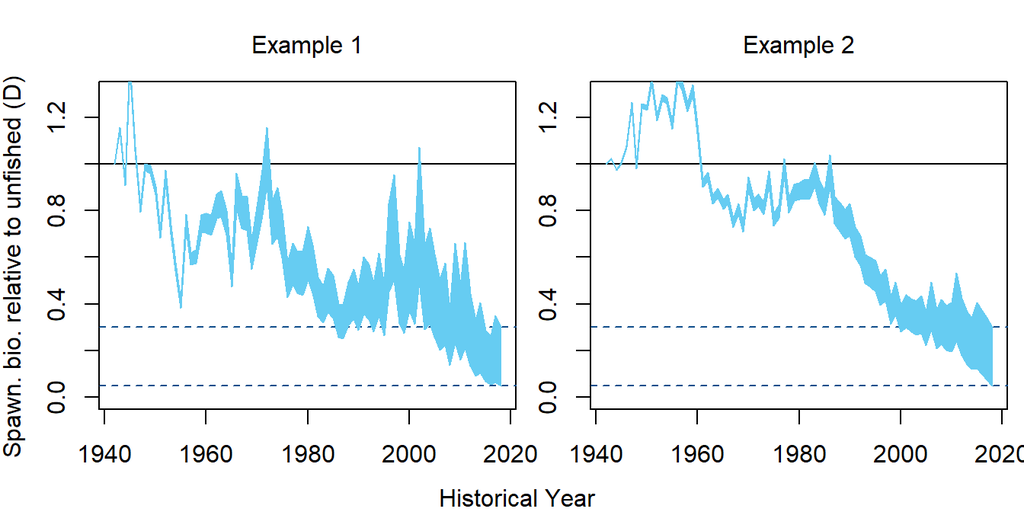

## Resilence

| Answered |
| --- |
| Not resilient (steepness < 0.3) |
| Low resilience (0.3 < steepness < 0.5) |
| Moderate resilence (0.5 < steepness < 0.7) |
| Resilient (0.7 < steepness < 0.9) |
| Very Resilient (0.9 < steepness) |

| Justification |
| --- |
| Steepness is fixed at 0.55 or 0.7. Given that steepness is not estimated and this is one-way trip data, it is fair to assume that chosen steepness is uncertain. |

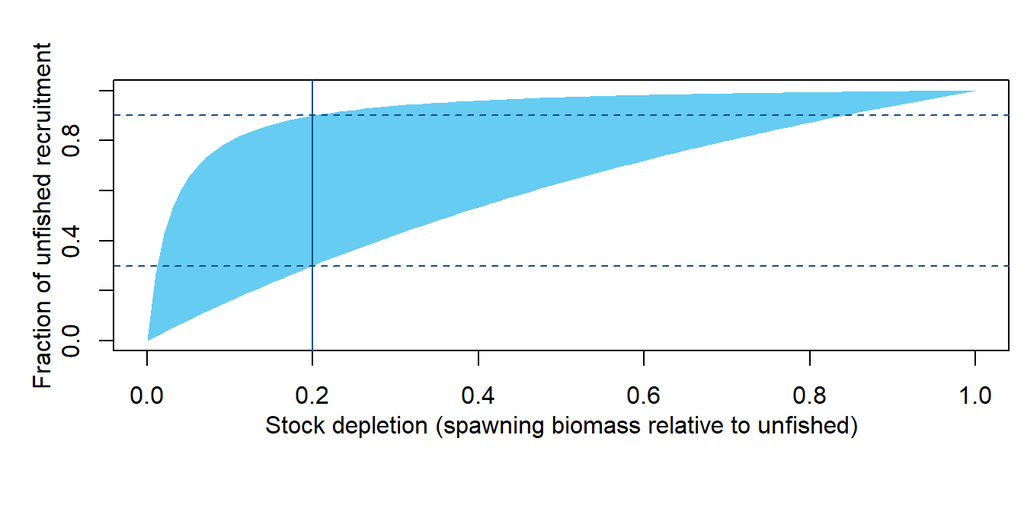

## Historical effort pattern

| Answered |
| --- |
| Stable |
| Two-phase |
| Boom-bust |
| Gradual increases |
| Stable, recent increases |
| Stable, recent declines |

[output not shown]

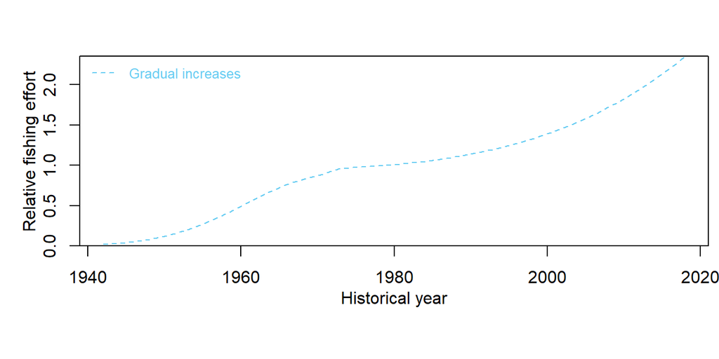

## Inter-annual variability in historical effort

| Answered |
| --- |
| Not variable (less than 20% inter-annual change (IAC)) |
| Variable (maximum IAC between 20% to 50%) |
| Highly variable (maximum IAC between 50% and 100%) |

| Justification |
| --- |
| Based on Figures J.5, J.9 and J.13 (Stanley 2009), there was an intermediate variability from year to year in exploitation rate. |

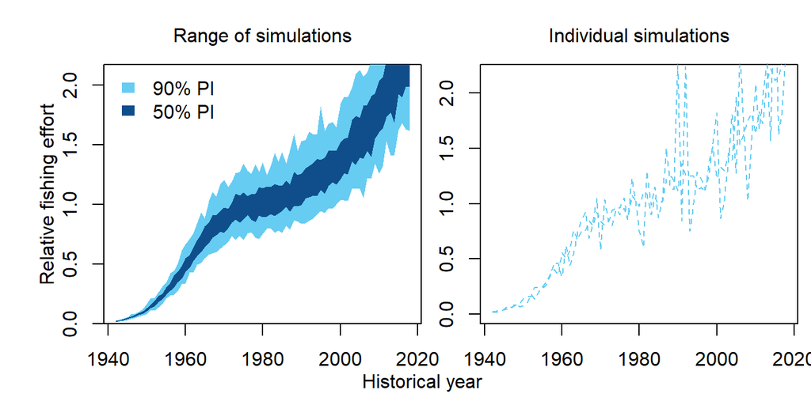

## Historical fishing efficiency changes

| Answered |
| --- |
| Declining by 2-3% pa (halves every 25-35 years) |
| Declining by 1-2% pa (halves every 35-70 years) |
| Stable -1% to 1% pa (may halve/double every 70 years) |
| Increasing by 1-2% pa (doubles every 35-70 years) |
| Increasing by 2-3% pa (doubles every 25-35 years) |

| Justification |
| --- |
| Efficiency changes unknown, however, with changes in technology and communication, it is reasonable to assume that it is stable to increasing. |

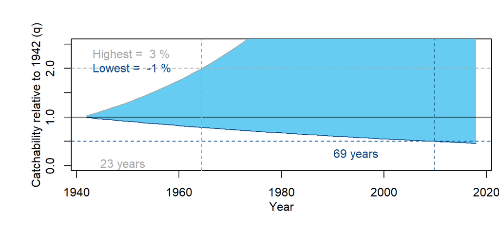

## Future fishing efficiency changes

| Answered |
| --- |
| Declining by 2-3% pa (halves every 25-35 years) |
| Declining by 1-2% pa (halves every 35-70 years) |
| Stable -1% to 1% pa (may halve/double every 70 years) |
| Increasing by 1-2% pa (doubles every 35-70 years) |
| Increasing by 2-3% pa (doubles every 25-35 years) |

| Justification |
| --- |
| No information could be found. It is reasonable that efficiency could increase with increases in technology; conversely, efficiency could decline as non-targeted fleets use technology to avoid bycatch |

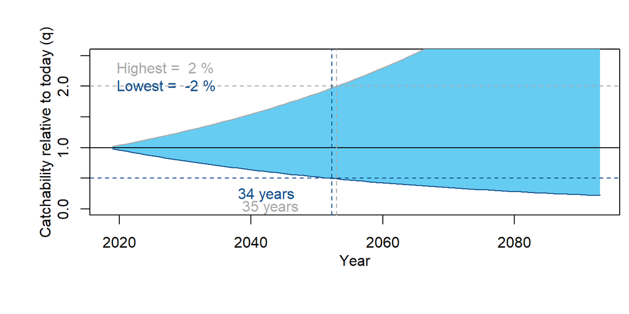

## Length at maturity

| Answered |
| --- |
| Very small (0.4 < LM < 0.5) |
| Small (0.5 < LM < 0.6) |
| Moderate (0.6 < LM < 0.7) |
| Moderate to large (0.7 < LM < 0.8) |
| Large (0.8 < LM < 0.9) |

[output not shown]

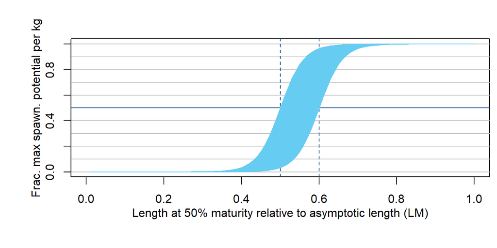

## Selectivity of small fish

| Answered |
| --- |
| Very small (0.1 < S < 0.2) |
| Small (0.2 < S < 0.4) |
| Half asymptotic length (0.4 < S < 0.6) |
| Large (0.6 < S < 0.8) |
| Very large (0.8 < S < 0.9) |

| Justification |
| --- |
| Selectivity is estimated in the assessment model. see Canary rockfish selectivity.png |

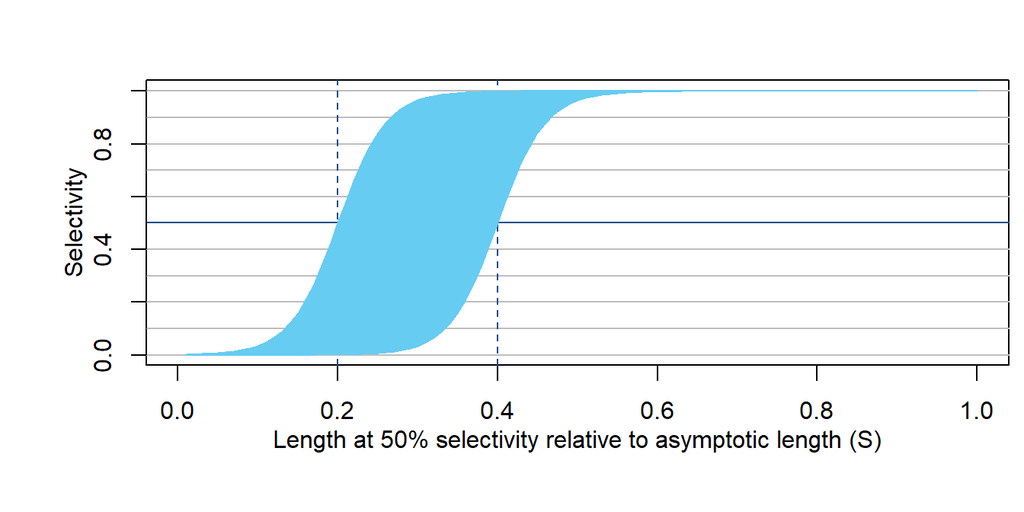

## Selectivity of large fish

| Answered |
| --- |
| Asymptotic selectivity (SL = 1) |
| Declining selectivity with length (0.75 < SL < 1) |
| Dome-shaped selectivity (0.25 < SL < 0.75) |
| Strong dome-shaped selectivity (SL < 0.25) |

| Justification |
| --- |
| Selectivity appears to be asymptotic. (see Canary rockfish selectivity.png) |

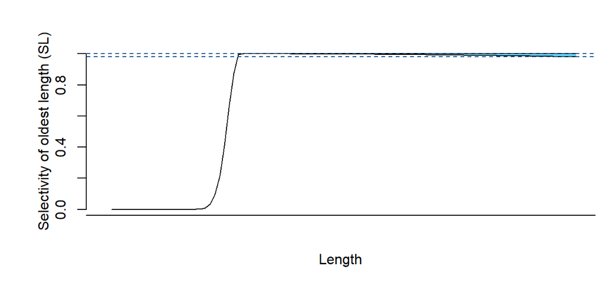

## Discard rate

| Answered |
| --- |
| Low (DR < 1%) |
| Low - moderate (1% < DR < 10%) |
| Moderate (10% < DR < 30%) |
| Moderate - high (30% < DR < 50%) |
| High (50% < DR < 70%) |

Justification

“We used observations of canary rockfish catch relative to halibut catch in the IPHC halibut survey for 2003-2005 to estimate a bycatch ratio of 0.006 (0.6%). We then estimate the incidental catch (discarded and retained) by applying this ratio to total halibut landings from B.C.”  
“Discard estimates are not available prior to 1996 and the establishment of the independent observer program.”  
“Discards for this species are minor, with generally less than 10 t per year recorded since 1996–97 for all areas (Table H.1).”  
(all quotes from Stanley et al. 2009. See also Table.H.1.png)  
(referring to the hook and line fishery): “These fleets now operate under a regulation of 100% retention of rockfish, with electronic review of discarding to confirm that discarding is negligible.” (Stanley et al. 2009)

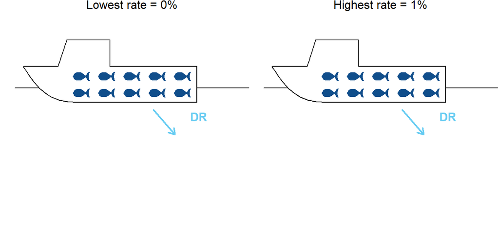

## Post-release mortality rate

| Answered |
| --- |
| Low (PRM < 5%) |
| Low - moderate (5% < PRM < 25%) |
| Moderate (25% < PRM < 50%) |
| Moderate - high (50% < PRM < 75%) |
| High (75% < PRM < 95%) |
| Almost all die (95% < PRM < 100%) |

[output not shown]

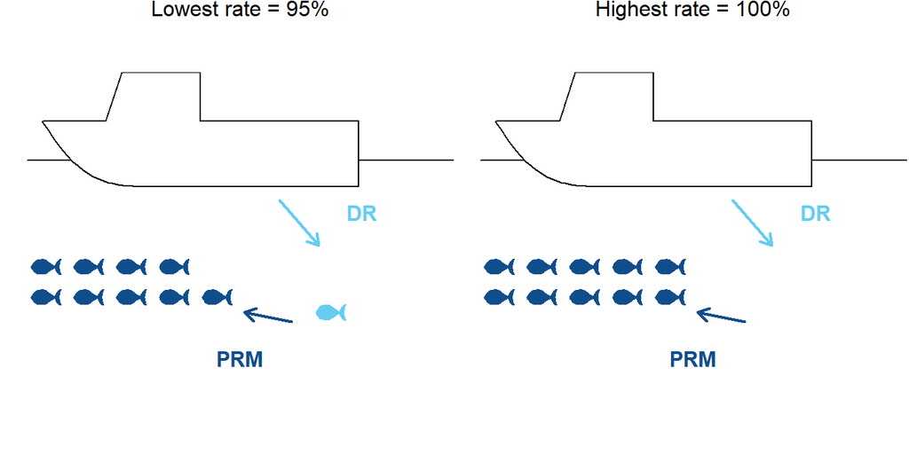